# HW 3

Christina Pham

2024-11-03

```r
library(tidyverse)
library(tidymodels)
library(ggplot2)
library(corrplot)
library(discrim)
titanic <- read_csv("homework-3-/homework-3-/data/titanic.csv")
titanic <- mutate(titanic, survived = factor(survived,
                           levels = c("Yes", "No")),
         pclass = as.factor(pclass))
```

### Question 1

```r
set.seed(1178)
titanic_split <- titanic %>%
  initial_split(prop = 0.75, strata = survived)

titanic_train <- training(titanic_split) # 667
titanic_test <- testing(titanic_split) #224
dim(titanic_train)
```

```
## [1] 667  12
```

```r
dim(titanic_test)
```

```
## [1] 224  12
```

```r
titanic_train %>%
  group_by(survived) %>%
  summarize(count = n()) #See output
```

```
## # A tibble: 2 × 2
##   survived count
##   <fct>    <int>
## 1 Yes        256
## 2 No         411
```

```r
#Missing data
colSums(is.na(titanic_train))  #counts the number of missing values(644)
```

```
## passenger_id     survived       pclass         name          sex          age
##            0            0            0            0            0          138
##       sib_sp        parch       ticket         fare        cabin     embarked
##            0            0            0            0          515            2
```

### Observation

Each dataset has approximately the correct number of observations, with 75% of the dataset (891 observations) being training (667), and the rest (224) being testing.

It is a good idea to use stratified sampling for this data since the output is not balanced, with more frequent observations for “No” (411) than “Yes” (256).

### Question 2

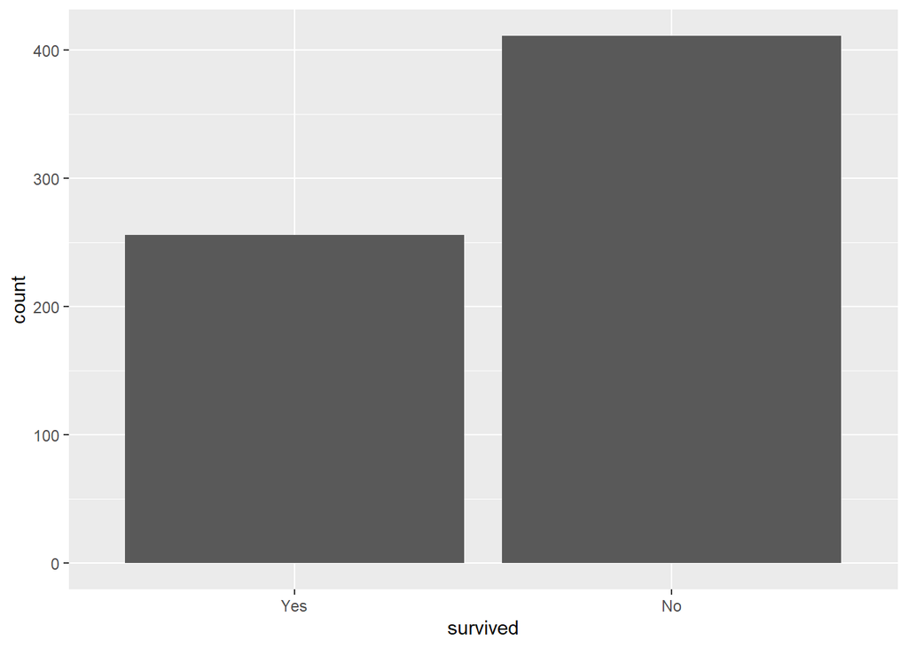

```r
#Bar Chart
titanic_train %>%
  ggplot(aes(x = survived)) +
  geom_bar()
```

Based on the bar chart, we see there are more observations in “No” than “Yes”.

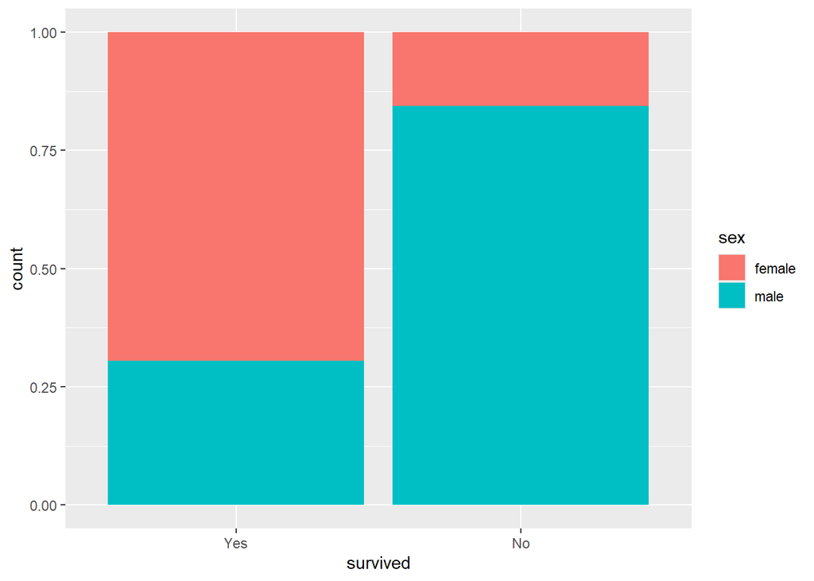

```r
titanic_train %>%
  ggplot(aes(x = survived, fill = sex)) +
  geom_bar(position = "fill")
```

Yes, `sex` is a good predictor for the outcome `survived`, with a higher amount of females surviving compared to males.

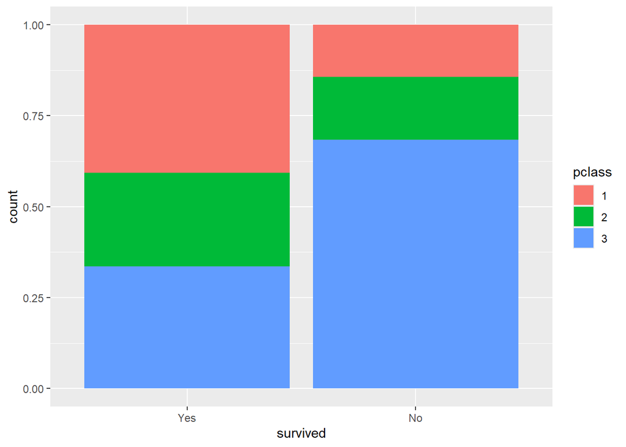

```r
titanic_train %>%
  ggplot(aes(x = survived, fill = pclass)) +
  geom_bar(position = "fill")
```

Yes, `pclass` is a good predictor of the outcome ‘survived’. We see that a higher percentage of third-class passengers did not survive compared to first and second-class.

It might be more useful to use a percent stacked bar chart as opposed to a traditional stacked bar chart since using proportions/percentages instead of total counts makes it easier to compare the relative survival rates within each category/level. It also lets us see the differences in the proportions of survivors vs. non-survivors within each separate category/level.

### Question 3

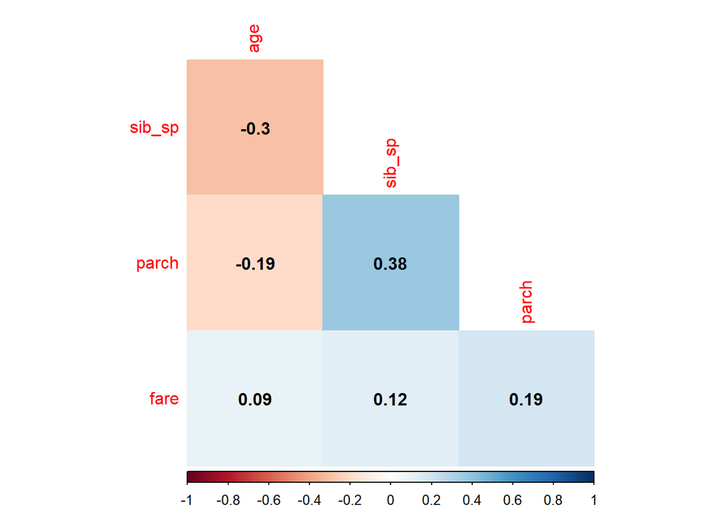

```r
titanic_train %>%
select(where(is.numeric), -passenger_id) %>%
  cor(use = "complete.obs") %>%
  corrplot(type = "lower", diag = FALSE,
           method = 'color', addCoef.col = 'black')
```

From the correlation matrix, we see `sib_sp` and `age` are negatively correlated with a coefficient of -0.3. This makes sense since as age increases, the older passenger on board the titanic is less likely to have siblings/their spouse aboard the Titanic. `Parch` and `age` also are negatively correlated with a coefficient of -0.19. This implies that older passengers are less likely to have their parents/children aboard the Titanic. Note that `parch` and `sib_sp` have the highest correlation coefficient & are positively correlated (0.38) which implies that the more parents aboard, the more siblings/spouses that are also aboard the Titanic. However, it is important to notice that `parch` and `sib_sp` are discrete variables.

### Question 4

```r
titanic_recipe <- recipe(survived ~ pclass + sex + age + sib_sp + parch + fare, data = titanic_train) %>%
  step_impute_linear(age, impute_with = imp_vars(sib_sp)) %>% #impute with sib_sp
  step_dummy(all_nominal_predictors()) %>%
  step_interact(~starts_with("sex"):fare + age:fare)
```

### Question 5

```r
titanic_logreg <- logistic_reg() %>%
  set_engine("glm") %>%
  set_mode("classification")

titanic_workflow <- workflow() %>%
  add_model(titanic_logreg) %>%
  add_recipe(titanic_recipe)

survived_fit1 <- fit(titanic_workflow, data = titanic_train)
```

### Question 6

```r
titanic_lda <- discrim_linear() %>%
  set_engine("MASS") %>%
  set_mode("classification")

titanic_workflow2 <- workflow() %>%
  add_model(titanic_lda) %>%
  add_recipe(titanic_recipe)

survived_lda <- fit(titanic_workflow2, data = titanic_train)
```

### Question 7

```r
titanic_qda <- discrim_quad() %>%
  set_engine("MASS") %>%
  set_mode("classification")

titanic_workflow3 <- workflow() %>%
  add_model(titanic_qda) %>%
  add_recipe(titanic_recipe)

survived_qda <- fit(titanic_workflow3, data = titanic_train)
```

### Question 8

```r
titanic_knn <- nearest_neighbor(neighbors =5) %>% #k = 5
  set_engine("kknn") %>%
  set_mode("classification")

titanic_workflow4 <- workflow() %>%
  add_model(titanic_knn) %>%
  add_recipe(titanic_recipe)

survived_knn <- fit(titanic_workflow4, data = titanic_train)
```

### Question 9

```r
predict(survived_fit1, new_data =  titanic_train, type = "prob") #Logistic
```

```
## # A tibble: 667 × 2
##    .pred_Yes .pred_No
##        <dbl>    <dbl>
##  1    0.0853    0.915
##  2    0.0739    0.926
##  3    0.0844    0.916
##  4    0.317     0.683
##  5    0.143     0.857
##  6    0.0288    0.971
##  7    0.780     0.220
##  8    0.0439    0.956
##  9    0.499     0.501
## 10    0.501     0.499
## # ℹ 657 more rows
```

```r
predict(survived_lda, new_data = titanic_train, type = "prob") #LDA
```

```
## # A tibble: 667 × 2
##    .pred_Yes .pred_No
##        <dbl>    <dbl>
##  1    0.0513    0.949
##  2    0.0424    0.958
##  3    0.0488    0.951
##  4    0.252     0.748
##  5    0.0859    0.914
##  6    0.0162    0.984
##  7    0.839     0.161
##  8    0.0311    0.969
##  9    0.590     0.410
## 10    0.611     0.389
## # ℹ 657 more rows
```

```r
predict(survived_qda, new_data = titanic_train, type = "prob") #QDA
```

```
## # A tibble: 667 × 2
##     .pred_Yes .pred_No
##         <dbl>    <dbl>
##  1 0.00494       0.995
##  2 0.00333       0.997
##  3 0.00398       0.996
##  4 0.0530        0.947
##  5 0.00813       0.992
##  6 0.123         0.877
##  7 0.408         0.592
##  8 0.00000107    1.00
##  9 0.316         0.684
## 10 0.000769      0.999
## # ℹ 657 more rows
```

```r
predict(survived_knn, new_data = titanic_train, type = "prob") #knn
```

```
## # A tibble: 667 × 2
##    .pred_Yes .pred_No
##        <dbl>    <dbl>
##  1    0.261     0.739
##  2    0         1
##  3    0.0844    0.916
##  4    0.261     0.739
##  5    0.0258    0.974
##  6    0.0844    0.916
##  7    0.529     0.471
##  8    0         1
##  9    0.529     0.471
## 10    0         1
## # ℹ 657 more rows
```

```r
#Use augment (similar to Hw2)
log_reg_roc <- augment(survived_fit1, new_data = titanic_train) %>%
  roc_auc(survived, .pred_Yes)
lda_roc <- augment(survived_lda, new_data = titanic_train) %>%
  roc_auc(survived, .pred_Yes)
qda_roc <- augment(survived_qda, new_data = titanic_train) %>%
  roc_auc(survived, .pred_Yes)
knn_roc <- augment(survived_knn, new_data = titanic_train) %>%
  roc_auc(survived, .pred_Yes)

all_roc <- bind_rows(log_reg_roc, lda_roc, qda_roc, knn_roc)

all_roc <- all_roc %>%
  data.frame() %>%
  mutate(models = c("Log", "LDA", "QDA", "KNN"))

all_roc
```

```
##   .metric .estimator .estimate models
## 1 roc_auc     binary 0.8672445    Log
## 2 roc_auc     binary 0.8660850    LDA
## 3 roc_auc     binary 0.8687652    QDA
## 4 roc_auc     binary 0.9868414    KNN
```

Based on our model performances, our KNN model performs the best with k = 5 under the ROC curve. We get an estimate of 0.986. However, this high accuracy may be due to overfitting. Meanwhile, logistic regression, LDA, and QDA perform similarly on the training data as these models.

### Question 10

```r
predict(survived_fit1, new_data =  titanic_test, type = "prob") #Logistic
```

```
## # A tibble: 224 × 2
##    .pred_Yes .pred_No
##        <dbl>    <dbl>
##  1    0.0734    0.927
##  2    0.220     0.780
##  3    0.411     0.589
##  4    0.528     0.472
##  5    0.379     0.621
##  6    0.0843    0.916
##  7    0.0664    0.934
##  8    0.0336    0.966
##  9    0.137     0.863
## 10    0.793     0.207
## # ℹ 214 more rows
```

```r
predict(survived_lda, new_data = titanic_test, type = "prob") #LDA
```

```
## # A tibble: 224 × 2
##    .pred_Yes .pred_No
##        <dbl>    <dbl>
##  1    0.0494    0.951
##  2    0.155     0.845
##  3    0.337     0.663
##  4    0.630     0.370
##  5    0.476     0.524
##  6    0.0487    0.951
##  7    0.0402    0.960
##  8    0.0244    0.976
##  9    0.0820    0.918
## 10    0.859     0.141
## # ℹ 214 more rows
```

```r
predict(survived_qda, new_data = titanic_test, type = "prob") #QDA
```

```
## # A tibble: 224 × 2
##     .pred_Yes .pred_No
##         <dbl>    <dbl>
##  1 0.000117      1.00
##  2 0.00972       0.990
##  3 0.168         0.832
##  4 0.0494        0.951
##  5 0.492         0.508
##  6 0.00395       0.996
##  7 0.00426       0.996
##  8 0.00000110    1.00
##  9 0.00766       0.992
## 10 0.777         0.223
## # ℹ 214 more rows
```

```r
predict(survived_knn, new_data = titanic_test, type = "prob") #knn
```

```
## # A tibble: 224 × 2
##    .pred_Yes .pred_No
##        <dbl>    <dbl>
##  1     0       1
##  2     0.445   0.555
##  3     0.916   0.0844
##  4     0.158   0.842
##  5     0.471   0.529
##  6     0       1
##  7     0       1
##  8     0       1
##  9     0.471   0.529
## 10     0.842   0.158
## # ℹ 214 more rows
```

```r
log_reg_roctest <- augment(survived_fit1, new_data = titanic_test) %>%
  roc_auc(survived, .pred_Yes)
lda_roctest <- augment(survived_lda, new_data = titanic_test) %>%
  roc_auc(survived, .pred_Yes)
qda_roctest <- augment(survived_qda, new_data = titanic_test) %>%
  roc_auc(survived, .pred_Yes)
knn_roctest <- augment(survived_knn, new_data = titanic_test) %>%
  roc_auc(survived, .pred_Yes)

all_roctest <- bind_rows(log_reg_roctest, lda_roctest, qda_roctest, knn_roctest)

all_roctest <- all_roctest %>%
  data.frame() %>%
  mutate(models = c("Log", "LDA", "QDA", "KNN"))

all_roctest
```

```
##   .metric .estimator .estimate models
## 1 roc_auc     binary 0.8273509    Log
## 2 roc_auc     binary 0.8270138    LDA
## 3 roc_auc     binary 0.8249916    QDA
## 4 roc_auc     binary 0.8412117    KNN
```

Based on the model performances, KNN achieved the highest AUC on the testing data (0.84).

### KNN model

```r
#Confusion matrix
augment(survived_knn, new_data = titanic_test) %>%
  conf_mat(truth = survived, estimate = .pred_class)
```

```
##           Truth
## Prediction Yes  No
##        Yes  63  20
##        No   23 118
```

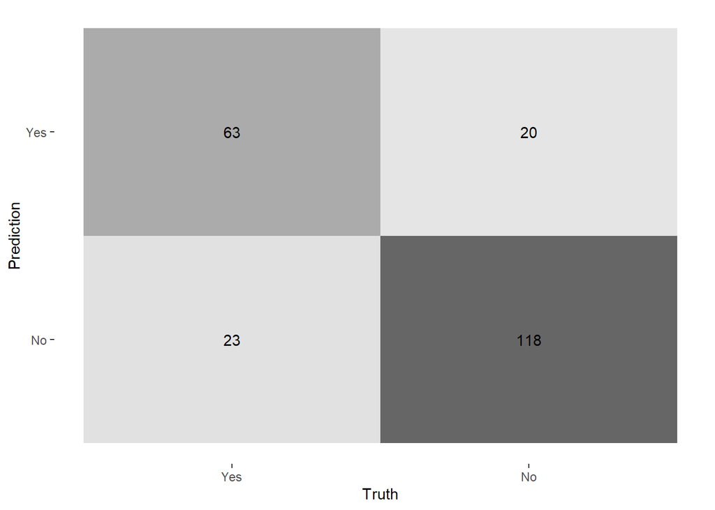

```r
#Confusion matrix visualization
augment(survived_knn, new_data = titanic_test) %>%
  conf_mat(truth = survived, estimate = .pred_class) %>%
  autoplot(type = "heatmap")
```

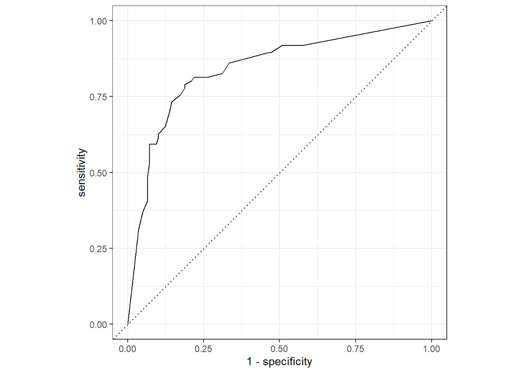

```r
#ROC Curve plot
augment(survived_knn, new_data = titanic_test) %>%
  roc_curve(survived, .pred_Yes) %>%
  autoplot()
```

### Question 11

$$p(z)=\frac{e^z}{1+e^z}$$
$$p(1+{e^z}) = {e^z}$$
$$p + p{e^z} = {e^z}$$
$$p = {e^z}- p({e^z)}$$
$$p = {e^z}(1-p)$$
$$\frac{p}{1-p} = {e^z}$$
$$ln(\frac{p}{1-p}) = z$$